# App-1) S&P 500 Returns

Stat 133, Fall 2024

Author

Gaston Sanchez

# About

The purpose of this assignment is to create a shiny app to explore and visualize daily fluctuations as well as different types of returns from the *Standard & Poor’s 500* (S&P 500) market index.

**Note**

In this assignment—which builds on top of HW6—you will have to create a shiny app, publish it on Posit’s shinyapps.io, and record a short video (of 3 mins max) showing how your app works and how to make sense of the displayed information.

# 1 S&P 500 Returns

Similar to HW6, we are going to work with data from the *Standard & Poor’s 500* (S&P 500) market index. Specifically, we are going to focus on two kinds of descriptive analysis:

1. **S&P 500 historical daily closing values.**
2. **S&P 500 multi-year returns.**

## 1.1 S&P 500 Historical Daily Closing Values

The first analysis has to do with visualizing the historical daily closing values. If you recall from HW6, the Wikipedia entry of the S&P 500 (https://en.wikipedia.org/wiki/S%26P_500), contains the graphic of a line chart depicting the daily closing values, specifically from January 3, 1950 to February 19, 2016 (see link below).

https://en.wikipedia.org/wiki/File:S_and_P_500_daily_linear_chart_1950_to_2016.png

## 1.2 S&P 500 Historical Multi-year Returns

The second analysis involves visualizing multi-year returns (e.g. 3-year returns, or 7-year returns, or any other number of years). You can get an idea for one of the graphics (bar chart of number-of-year returns over time) in the following Macrotrends webpage:

https://www.macrotrends.net/2526/sp-500-historical-annual-returns

# 2 Shiny App

The main goal of this assignment is to create a shiny app to:

1. Visualize a timeline of S&P 500 historical daily (closing) values.
2. Visualize a bar chart (over time) of S&P 500 multi-year returns.
3. Display a chart (i.e. table) containing summary statistics of S&P 500 multi-year returns.

A hypothetical example of the app’s structure is displayed below (more details provided in the following subsection).

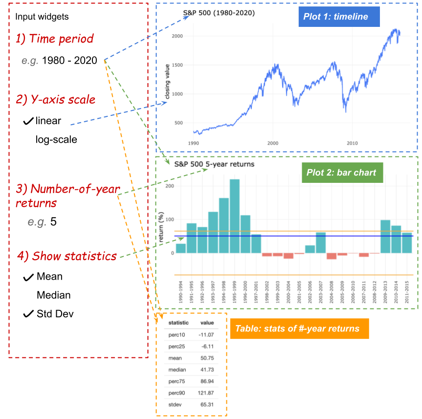

Figure 1: Main app components.

## 2.1 Shiny App Layout

Your app should have a layout like the following diagram (see specifications below). You can find a template R script file `app-template.R` in: **Files/hws/app1/app-template.R**

https://bcourses.berkeley.edu/courses/1536526/files/folder/hws/app1

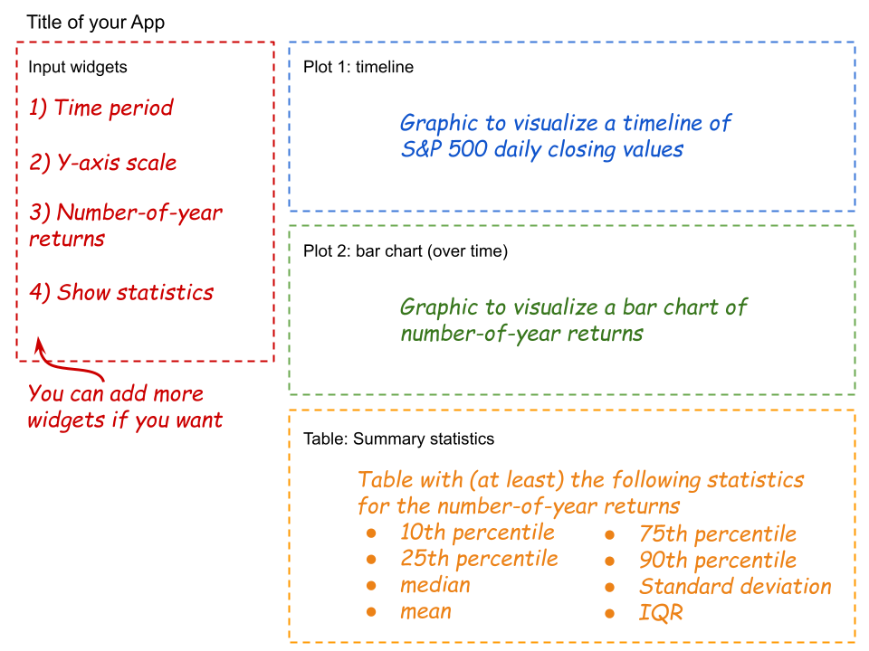

Figure 2: Diagram illustrating the general layout of the app.

- **Title**: main title for your app (give it a meaningful name).
- **Input widgets**: widgets arranged in a sidebar panel.
- **Plot 1**: an output graphic to display a timeline of daily closing values.
- **Plot 2**: an output graphic to display a bar chart (over time) of S&P 500 returns given a certain number of years.
- **Table**: an output area (e.g. for a table) to display numeric summaries of S&P 500 returns given a certain number of years.

## 2.2 Input widgets

Your app should include widgets for the inputs listed below. You are also allowed to include more widgets in addition to the required ones.

1. `sliderInput()` for the **time period**, ranging from 1928 to 2023. Default chosen values from 1990 to 2020.
2. `radioButtons()` with choices to select the **scale of the timeline**: a) linear scale, or b) logarithmic scale (log-10). This is to control the scale in the y-axis of **plot 1**.
3. `numericInput()` or `sliderInput()` to select the **number of years** for computing multi-year returns. Default value of 5 years. This widget directly affects the data behind **plot 2**, and the derived statistics in the **table** output.
4. `checboxGroup()` or `selectInput()` so that the user can choose which **summary statistics** to be superimposed (as horizontal lines) in **plot 2**. Provide at least 3 choices: mean return, median return, and standard deviation. By default, no statistics are shown in plot 2.

As we said, you are allowed to include more widgets that enhance the user experience, or that provide deeper insight into understanding the behavior of the S&P 500 index.

# 3 Submission

Your submission should include the following:

- 📄 R File
- 🔗 Link to published app
- 🎬 Link to video

## 3.1 📄 R File

You will have to submit—in bCourses—the `app.R` file (do NOT confuse with a `qmd` file) containing the code of your app.

## 3.2 🔗 Link to published app

You will also have to submit the link to your published app in [shinyapps.io](https://www.shinyapps.io/) (the free version). Share the link with us in the comments section of the submission in bCourses.

As you were able to tell from lab-9, this publication process is fairly straightforward. In the unlikely event that you need to start from scratch, follow the steps described in the file `publish-to-shinyapps.html`

https://bcourses.berkeley.edu/courses/1531596/files/folder/readings?preview=87786097

## 3.3 🎬 Link to Video

In addition to the `app.R` file, you will also have to record a video—maximum length of 3 minutes—with both **screen and face** capture, in which you show us your published shiny app, how to use it, and a description of the produced visualizations. Share the **public link** with us in the comments section of the submission in bCourses.

We recommend recording the video using your Zoom Berkeley account, and then sharing with us the **public link**. If you use this option, please adjust the recording settings so that the video expires after Dec-31-2024. Optionally, you can also record a video using other tools of your preference. Likewise, you can upload your video to your google drive account, or youtube, or vimeo, or a similar video-hosting platform.

Regardless of where you decide to host the file of your video, you must share the **public link** (don’t make it private) in bCourses: use the “comments section” of the submission to add this link as a comment. To be clear: do NOT upload the video to bCourses, just its link.

Make sure that the video does not exceed 3-min, that its resolution is okay, without too much background noise, avoid very low volume or inaudible audio, and also ensure that your image is stable (don’t make us watch a shaky video).

## Rubric

Roughly speaking, the code of the app (app.R) is worth about 70%, the video is worth about 20%, and the published app (shinyapps.io) is about 10%.

**0 pts:**

- Didn’t attempt or very very wrong/poor.

**1-2 pts:**

- Got started and made initial progress, but went off in the wrong direction or with no clear direction. And/or mostly incomplete.

**3-4 pts:**

- Got started and made some progress, but submission elements are highly incomplete or have major/fatal issues.

**5 pts:**

- Somewhat in the right direction and got half-way there.
- All elements (app.R, shinyapps.io, video) are submitted; app has major/fatal issues.
- shinyapps.io AND video missing or not working (app.R submitted); code in app is mostly complete but has major issues.

**6 pts:**

- shinyapps.io AND video missing (app.R submitted); app has some minor thing missing or wrong.

**7 pts:**

- shinyapps.io AND video missing or don’t work (app.R submitted); app is complete and works okay.
- Video missing or not working (app.R and shinyapps.io are submitted); app has minor issues.
- All elements (app.R, shinyapps.io, video) are submitted; app has major issues.

**8 pts:**

- Video missing (app.R and shinyapps.io are submitted); app is complete and works okay.
- All elements (app.R, shinyapps.io, video) are submitted; app/video has various minor issues.

**9 pts:**

- shinyapps.io missing or does not work (app.R and video are submitted); app is complete and works okay.
- All elements (app.R, shinyapps.io, video) are submitted; app/video mostly right but a minor thing missing or wrong.

**10 pts:**

- All elements (app.R, shinyapps.io, video) are submitted; 100% complete, meets all requirements, everything works as expected, video is well recorded and explanations/descriptions are good and sound.